# Simulation Results

AMM

18 October, 2017

## Composite Methods

- DC - Simple method we discussed in DC
- Thirds – approach splitting data into 3
- R_CV – uses CV error
- R_OpErr – uses Op-Corr apparent error
- R_AppRes – ‘apparent error’ using actual response
- R_AppCI – ‘apparent error’ using ci response

## Friedman 1 - Simulation

- $$X_{1}, \cdots,X_{9} \sim U(0,1)$$
- $$Y= 10 \sin(\pi X_1\ast X_2)+20(X_{3}-.5)^2+10X_4+5X_{5}+\epsilon$$
- $$\epsilon \sim N(0,1)$$

There are 500 simulations performed for all methods.

## Notes from Meeting on 10/11/2017:

1. add CART on for comparison - plain old CART
2. increase sample sizes for training set 5k and 10k test set
3. try running with alpha = 1
4. do histograms of estimated sigma squared and alphas

## Third scenario – updated from 10/11 with all 500 sims and CART

### With a grid for lambda and 500 in the training set and 1000 in the test set

### Prediction error of difference between True outcome and predicted outcome.

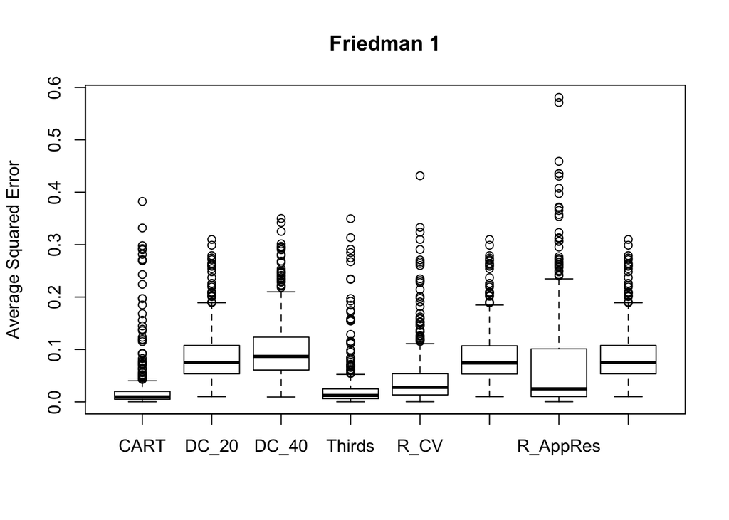

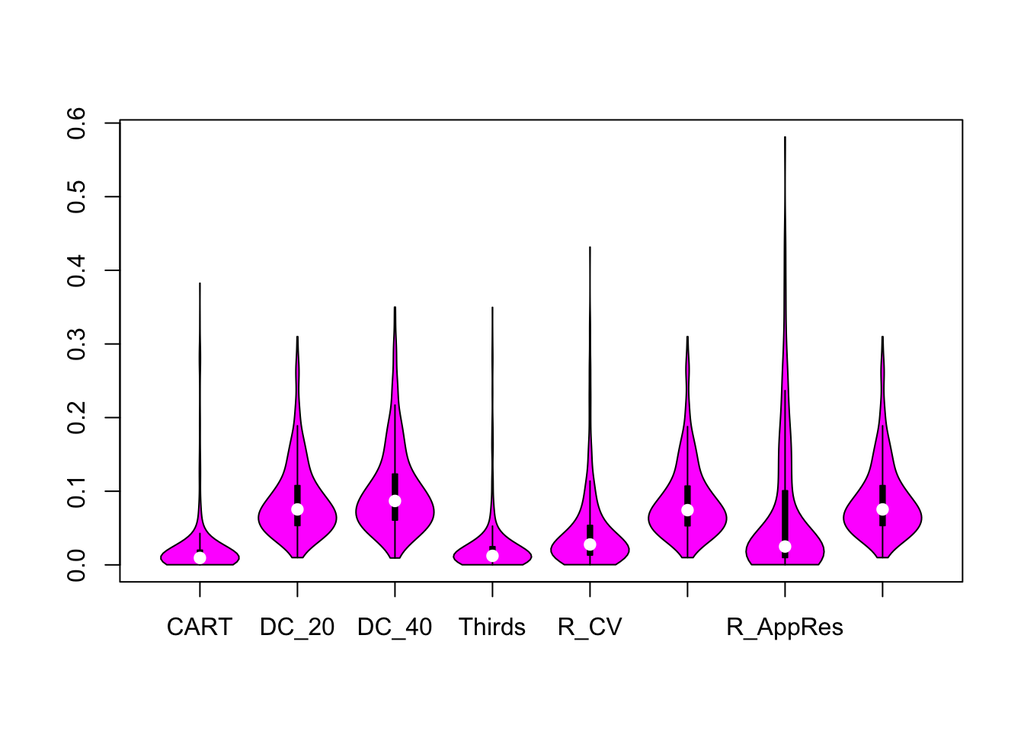

```
##  CART                  DC_20                DC_40
##  "Min.   :0.0001809  " "Min.   :0.009858  " "Min.   :0.009342  "
##  "1st Qu.:0.0047880  " "1st Qu.:0.053445  " "1st Qu.:0.060839  "
##  "Median :0.0094391  " "Median :0.075320  " "Median :0.086814  "
##  "Mean   :0.0229733  " "Mean   :0.088429  " "Mean   :0.100909  "
##  "3rd Qu.:0.0199365  " "3rd Qu.:0.107629  " "3rd Qu.:0.123297  "
##  "Max.   :0.3824763  " "Max.   :0.309920  " "Max.   :0.350009  "
##  Thirds                R_CV                 R_OpErr
##  "Min.   :0.0001463  " "Min.   :0.000253  " "Min.   :0.009858  "
##  "1st Qu.:0.0059990  " "1st Qu.:0.013310  " "1st Qu.:0.053100  "
##  "Median :0.0122403  " "Median :0.027684  " "Median :0.074323  "
##  "Mean   :0.0247645  " "Mean   :0.044498  " "Mean   :0.087794  "
##  "3rd Qu.:0.0246743  " "3rd Qu.:0.053536  " "3rd Qu.:0.106974  "
##  "Max.   :0.3496707  " "Max.   :0.431520  " "Max.   :0.309920  "
##  R_AppRes              R_AppCI
##  "Min.   :0.0002778  " "Min.   :0.009858  "
##  "1st Qu.:0.0100089  " "1st Qu.:0.053445  "
##  "Median :0.0248950  " "Median :0.075320  "
##  "Mean   :0.0681198  " "Mean   :0.088429  "
##  "3rd Qu.:0.1006540  " "3rd Qu.:0.107629  "
##  "Max.   :0.5810510  " "Max.   :0.309920  "
```

## Third Scenario - now looking at lambda values – updated from 10/11 with all 500 sims and CART

### With a grid for lambda and 500 in the training set and 1000 in the test set

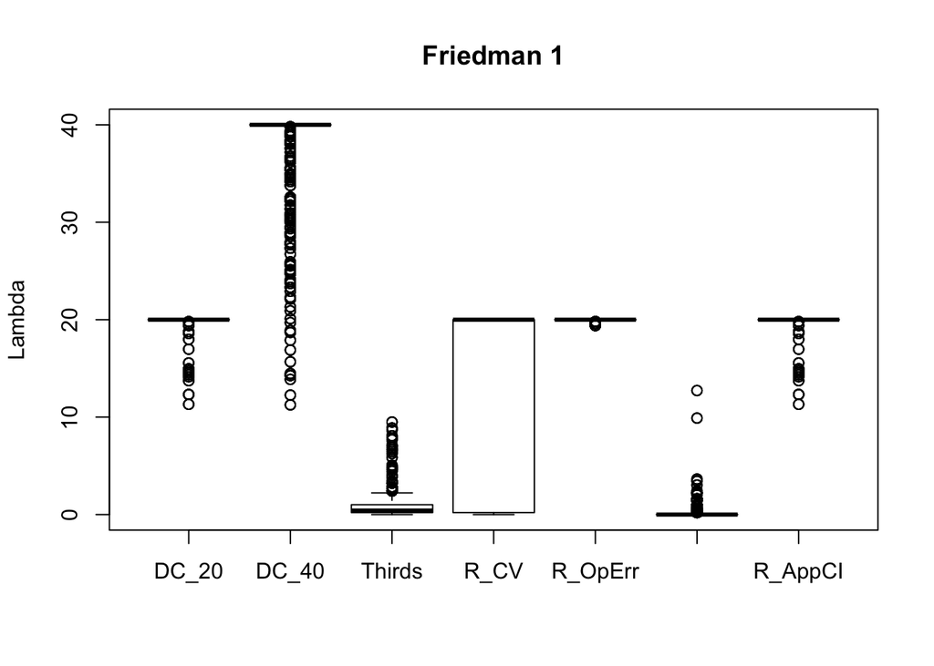

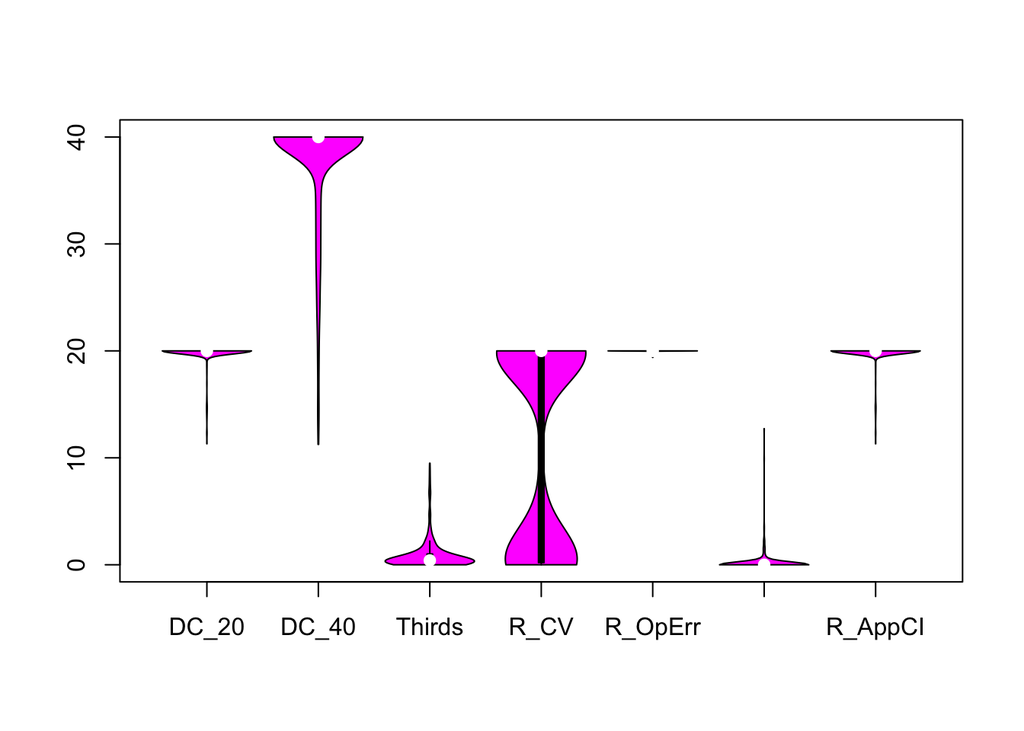

```
##  DC_20             DC_40             Thirds             R_CV
##  "Min.   :11.31  " "Min.   :11.26  " "Min.   :0.0000  " "Min.   : 0.000  "
##  "1st Qu.:20.00  " "1st Qu.:40.00  " "1st Qu.:0.2020  " "1st Qu.: 0.202  "
##  "Median :20.00  " "Median :40.00  " "Median :0.4040  " "Median :20.000  "
##  "Mean   :19.85  " "Mean   :37.79  " "Mean   :0.8824  " "Mean   :11.066  "
##  "3rd Qu.:20.00  " "3rd Qu.:40.00  " "3rd Qu.:1.0101  " "3rd Qu.:20.000  "
##  "Max.   :20.00  " "Max.   :40.00  " "Max.   :9.4949  " "Max.   :20.000  "
##  R_OpErr           R_AppRes            R_AppCI
##  "Min.   :19.39  " "Min.   : 0.0000  " "Min.   :11.31  "
##  "1st Qu.:20.00  " "1st Qu.: 0.0000  " "1st Qu.:20.00  "
##  "Median :20.00  " "Median : 0.0000  " "Median :20.00  "
##  "Mean   :19.99  " "Mean   : 0.1592  " "Mean   :19.85  "
##  "3rd Qu.:20.00  " "3rd Qu.: 0.0000  " "3rd Qu.:20.00  "
##  "Max.   :20.00  " "Max.   :12.7273  " "Max.   :20.00  "
```

## ALPHA = 1 - with 192 complete on Rob’s

### With a grid for lambda and 500 in the training set and 1000 in the test set

### Prediction error of difference between True outcome and predicted outcome.

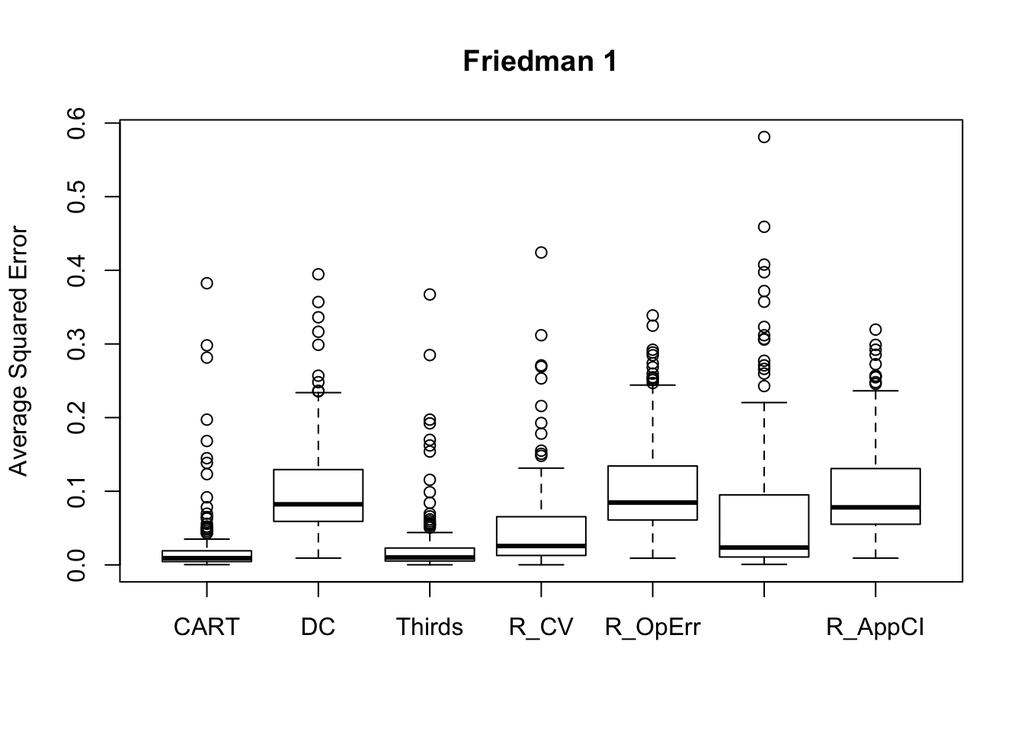

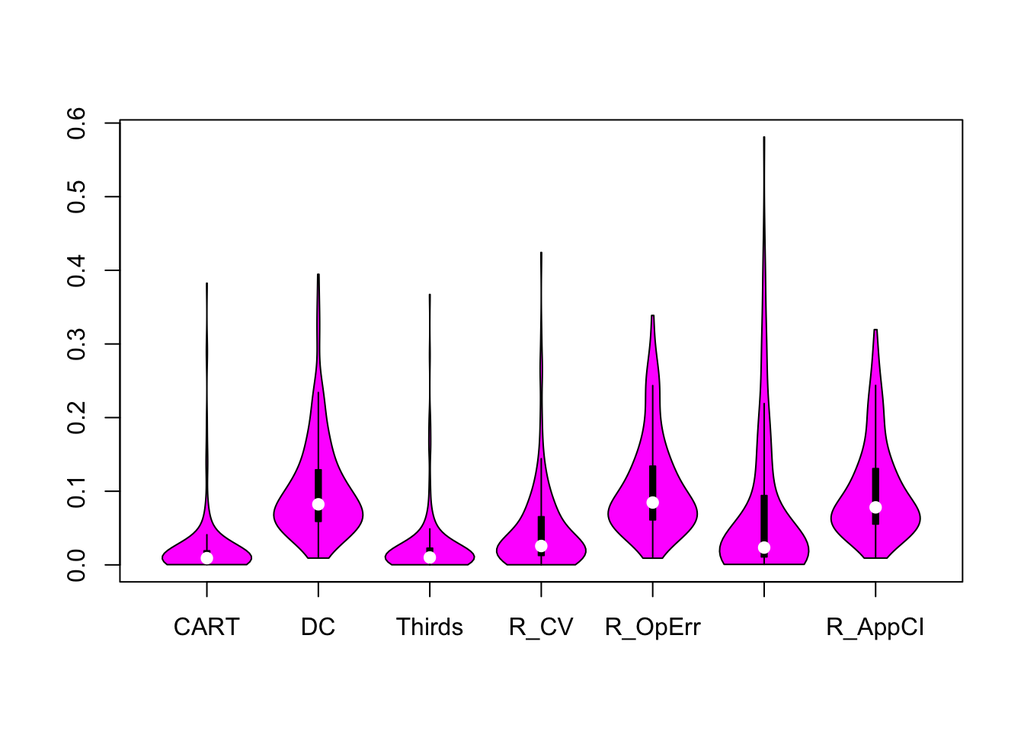

```
##  CART                  DC                   Thirds
##  "Min.   :0.0001809  " "Min.   :0.009203  " "Min.   :0.0001536  "
##  "1st Qu.:0.0047880  " "1st Qu.:0.058946  " "1st Qu.:0.0055431  "
##  "Median :0.0094391  " "Median :0.083525  " "Median :0.0114241  "
##  "Mean   :0.0229733  " "Mean   :0.103027  " "Mean   :0.0228463  "
##  "3rd Qu.:0.0199365  " "3rd Qu.:0.126482  " "3rd Qu.:0.0217127  "
##  "Max.   :0.3824763  " "Max.   :0.394621  " "Max.   :0.3671912  "
##  R_CV                  R_OpErr              R_AppRes
##  "Min.   :0.0001566  " "Min.   :0.009055  " "Min.   :0.0006582  "
##  "1st Qu.:0.0127876  " "1st Qu.:0.061128  " "1st Qu.:0.0108446  "
##  "Median :0.0256494  " "Median :0.084640  " "Median :0.0235046  "
##  "Mean   :0.0468042  " "Mean   :0.107505  " "Mean   :0.0685264  "
##  "3rd Qu.:0.0653577  " "3rd Qu.:0.134076  " "3rd Qu.:0.0941293  "
##  "Max.   :0.4242058  " "Max.   :0.338731  " "Max.   :0.5810510  "
##  R_AppCI
##  "Min.   :0.009203  "
##  "1st Qu.:0.055426  "
##  "Median :0.078104  "
##  "Mean   :0.101625  "
##  "3rd Qu.:0.130737  "
##  "Max.   :0.319503  "
```

## ALPHA = 1 - with 192 complete on Rob’s

### With a grid for lambda and 500 in the training set and 1000 in the test set

### Lambda chosen for each method (all limited to a grid of 0 to 20 for lambda with 100 points)

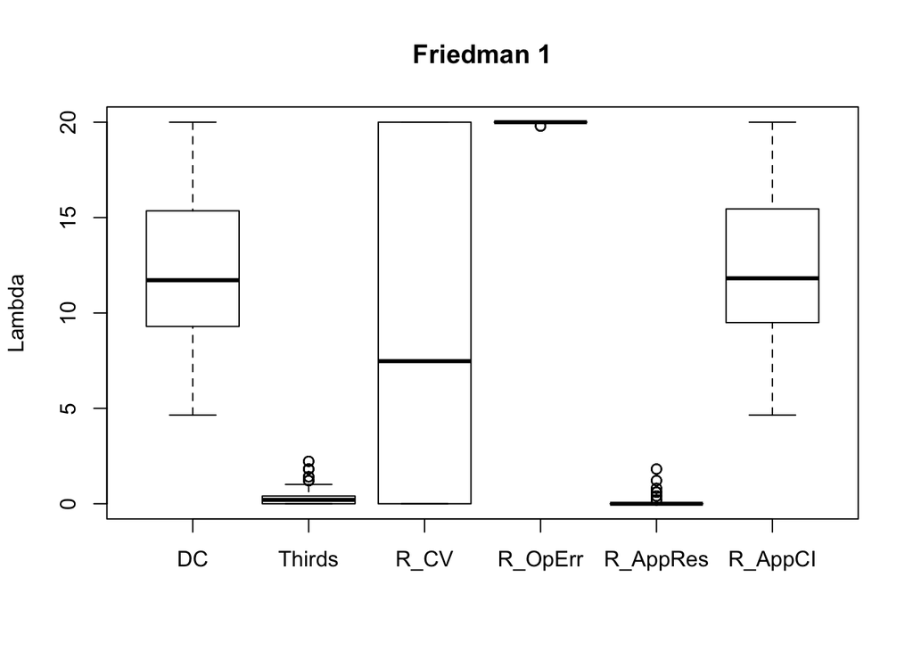

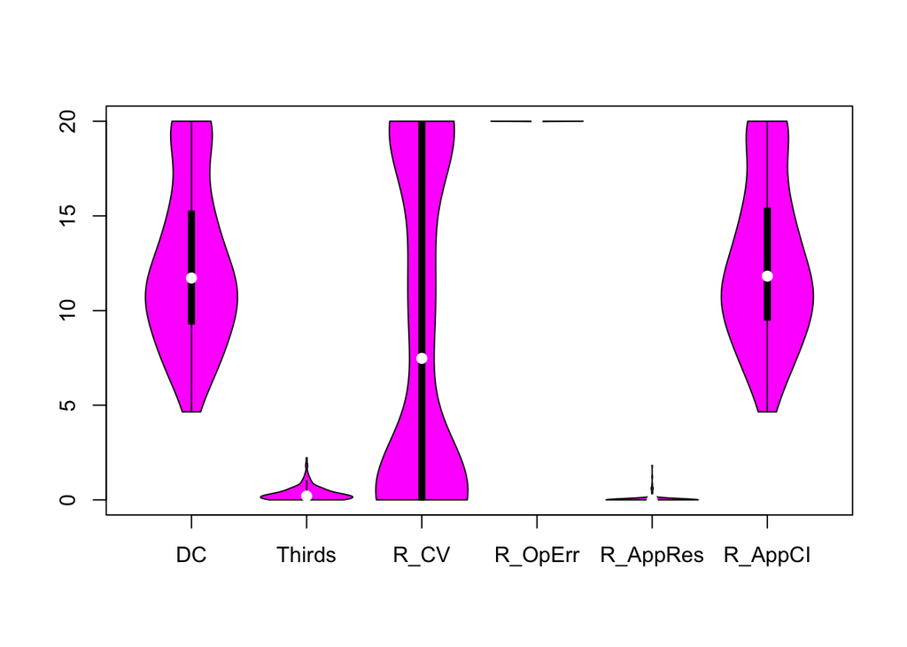

[output not shown]

## ALPHAS & sigma squared for 1 run of each method

## DC Method

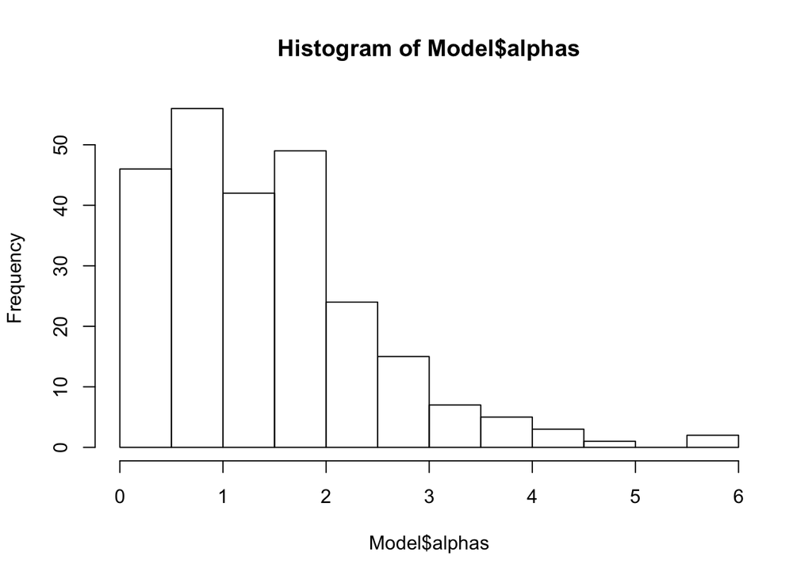

```r
  hist(Model$alphas)
```

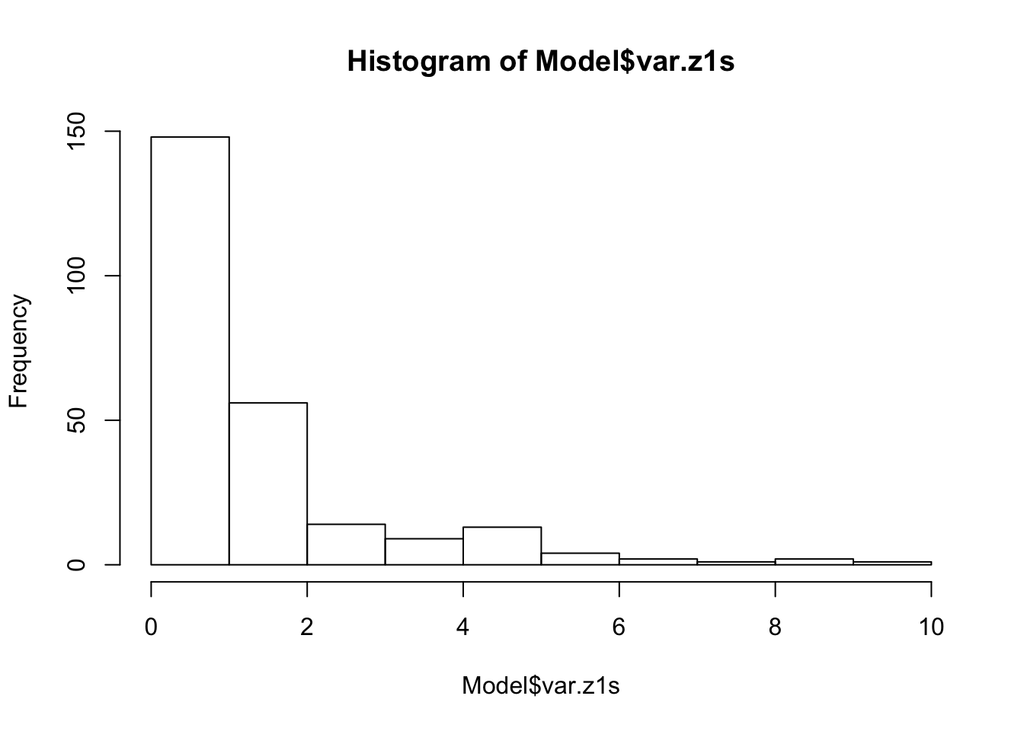

```r
  hist(Model$var.z1s)
```

## Thirds Method

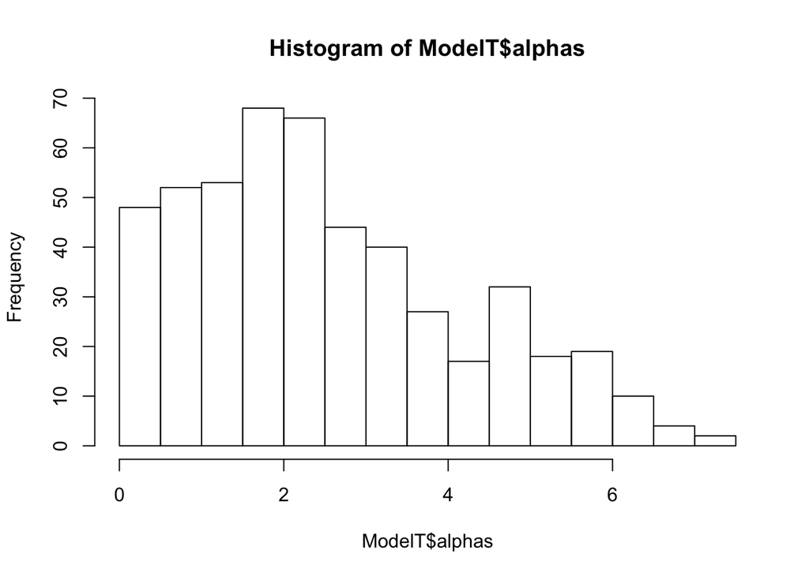

```r
  hist(ModelT$alphas)
```

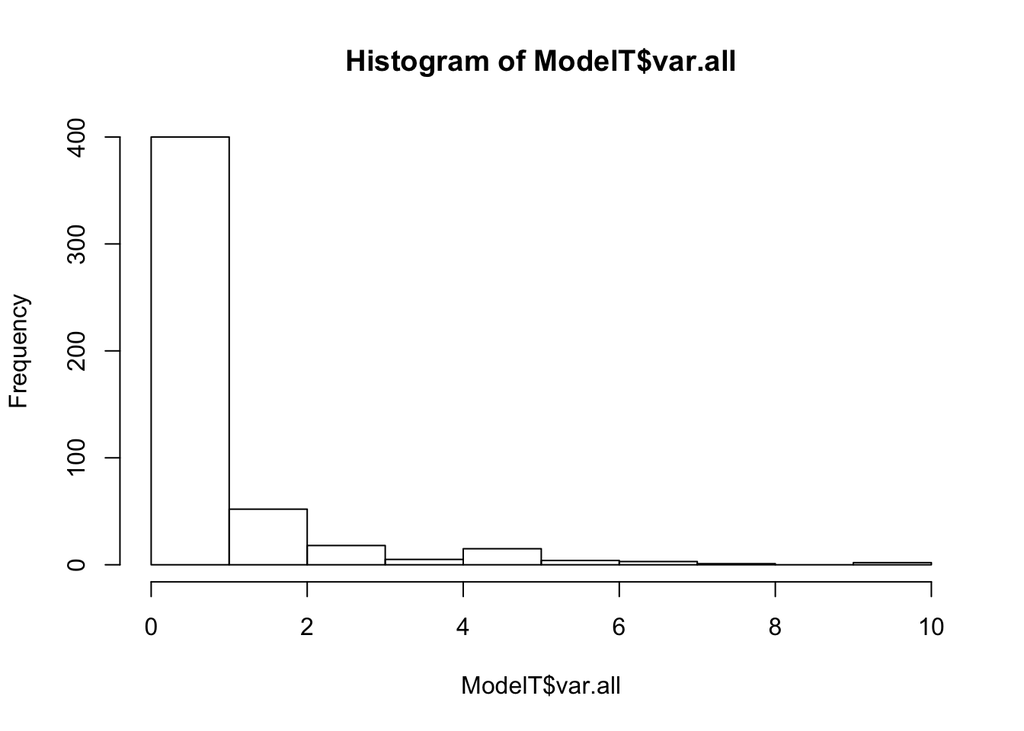

```r
  hist(ModelT$var.all)
```

## Rob’s Method

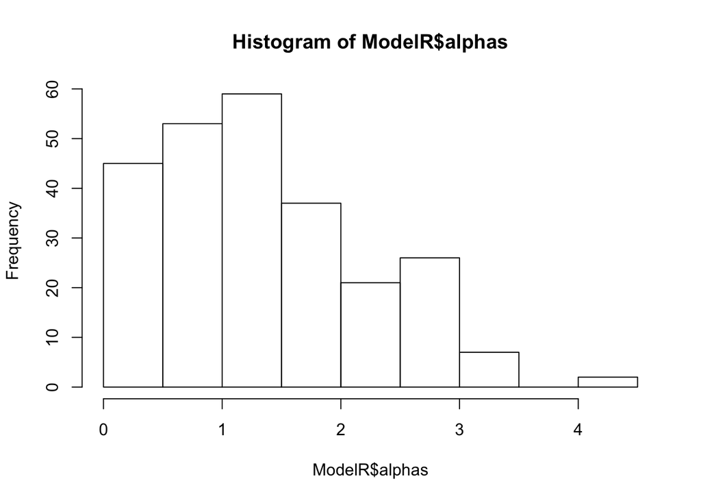

```r
  hist(ModelR$alphas)
```

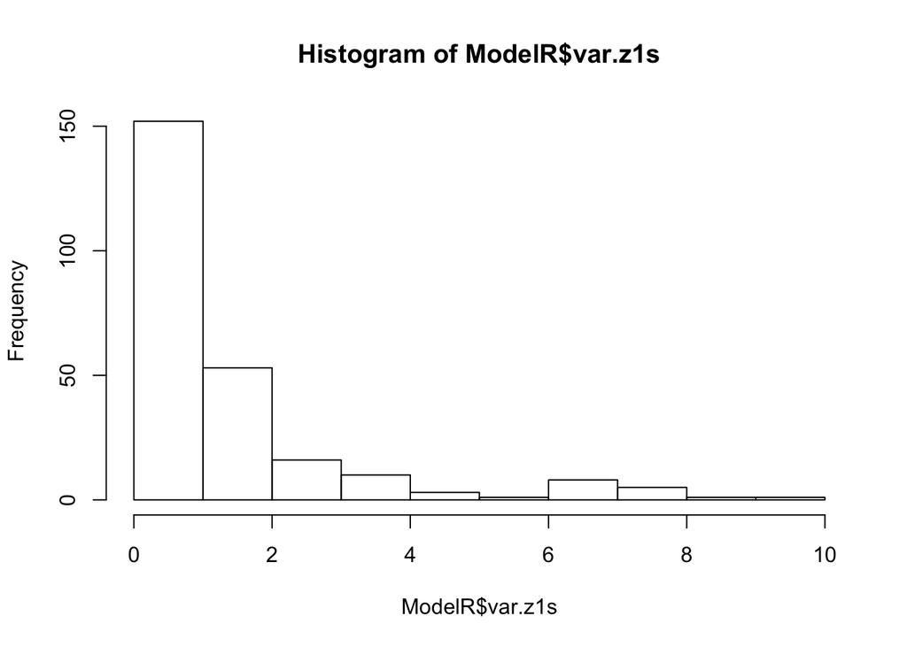

```r
  hist(ModelR$var.z1s)
```